# Report

```python
import pandas as pd
import glob

def get_dataframe(path):
    all_files = glob.glob(path + "/*.csv")

    all_data = []
    all_clinics = []

    print("Data from:")
    for filename in all_files:
        df = pd.read_csv(filename, index_col=None, header=0)

        clinic_name = filename.split('\\')[1].replace('.csv', ' ')
        length = len(df.index)
        df["clinicName"] = (clinic_name*length).split(' ')[:-1]

        all_data.append(df)
        all_clinics.append(clinic_name)
        print(clinic_name)

    frame = pd.concat(all_data, axis=0, ignore_index=True)
    return frame, all_clinics
```

## KL, JB, Penang Review Data Scraped from Google Review

```python
path = './raw/KL'
kl_data, kl_clinics = get_dataframe(path)
kl_data
```

```
Data from:
Dr_Lynn_Face_Clinic
EE_CLINIC_-_Premium_Aesthetic,_Laser_%26_Skin_Clinic
Health_Pathway_Clinic
Klinik_Hana_Laser_%26_Aesthetic_Clinic_(kl_branch)
Lifestyle_Clinic
Nexus_Clinic_Kuala_Lumpur_(Skin_%26_Hair_Aesthetic_Clinic)
RJ_CLINIC
RJ_CLINIC_(AESTHETIC_@_ATIVO_DAMANSARA)
SIGNATURE_CLINIC
```

|  | fullNames | postDates | starRatings | postReviews | totalReviews | aggregateRating | clinicName |
| --- | --- | --- | --- | --- | --- | --- | --- |
| 0 | New Gadget Store | a year ago | 5 | love there service so much | 5 | 5.0 | Dr_Lynn_Face_Clinic |
| 1 | Sole Mate | 2 years ago | 5 | Awesome! Very nice and friendly staff. | 5 | 5.0 | Dr_Lynn_Face_Clinic |
| 2 | NRLYN 7 | 2 years ago | 5 | The best one in town, highly recommended! | 5 | 5.0 | Dr_Lynn_Face_Clinic |
| 3 | muhd fauzan | 2 years ago | 5 | NaN | 5 | 5.0 | Dr_Lynn_Face_Clinic |
| 4 | lynn zamani | 2 years ago | 5 | NaN | 5 | 5.0 | Dr_Lynn_Face_Clinic |
| 5 | Siew Yeng | 4 days ago | 5 | Highly recommended 👍\nDr & assistant very prof... | 19 | 5.0 | EE_CLINIC_-_Premium_Aesthetic,_Laser_%26_Skin_... |
| 6 | William Chiew | a month ago | 5 | Friendly & professional staff. The environment... | 19 | 5.0 | EE_CLINIC_-_Premium_Aesthetic,_Laser_%26_Skin_... |
| 7 | Jh T | 4 days ago | 5 | Awesome and caring Doctor Ee. Very knowledgab... | 19 | 5.0 | EE_CLINIC_-_Premium_Aesthetic,_Laser_%26_Skin_... |
| 8 | Ni Han | a month ago | 5 | Highly recommended\nService alsoo soo good\nTh... | 19 | 5.0 | EE_CLINIC_-_Premium_Aesthetic,_Laser_%26_Skin_... |
| 9 | Mabel | 3 months ago | 5 | Highly recommended!\nExcellent customer servic... | 19 | 5.0 | EE_CLINIC_-_Premium_Aesthetic,_Laser_%26_Skin_... |
| 10 | S Mayaa | 11 months ago | 5 | I went there yesterday to discuss about my Por... | 19 | 5.0 | EE_CLINIC_-_Premium_Aesthetic,_Laser_%26_Skin_... |
| 11 | Thila Karuppiah | a year ago | 5 | Highly recommended .. \nExcellent service and ... | 19 | 5.0 | EE_CLINIC_-_Premium_Aesthetic,_Laser_%26_Skin_... |
| 12 | ayen radzi | a year ago | 5 | Tq for ur services, we as customer very comfor... | 19 | 5.0 | EE_CLINIC_-_Premium_Aesthetic,_Laser_%26_Skin_... |
| 13 | Funian Wong | a year ago | 5 | Ee clinic is quite good. \nReasonable price an... | 19 | 5.0 | EE_CLINIC_-_Premium_Aesthetic,_Laser_%26_Skin_... |
| 14 | Siti Nur Aliyah binti Zambri | 2 years ago | 5 | Excellent service.\nAttentive and hospitable.\... | 19 | 5.0 | EE_CLINIC_-_Premium_Aesthetic,_Laser_%26_Skin_... |
| 15 | leonard tan | a year ago | 5 | Location - strategic location facing open car ... | 19 | 5.0 | EE_CLINIC_-_Premium_Aesthetic,_Laser_%26_Skin_... |
| 16 | Brian Lee | 2 years ago | 5 | I always wanted to improve my skin texture... ... | 19 | 5.0 | EE_CLINIC_-_Premium_Aesthetic,_Laser_%26_Skin_... |
| 17 | Shally Ong | 2 years ago | 5 | Highly recommended if you are looking for extr... | 19 | 5.0 | EE_CLINIC_-_Premium_Aesthetic,_Laser_%26_Skin_... |
| 18 | SIAN VEI HOONG | a year ago | 5 | What a good facial treatment experience here. | 19 | 5.0 | EE_CLINIC_-_Premium_Aesthetic,_Laser_%26_Skin_... |
| 19 | yi sam | 3 months ago | 5 | (Translated by Google) When my face is helples... | 19 | 5.0 | EE_CLINIC_-_Premium_Aesthetic,_Laser_%26_Skin_... |
| 20 | Nana Sam | 3 months ago | 5 | (Translated by Google) The doctors and nurses ... | 19 | 5.0 | EE_CLINIC_-_Premium_Aesthetic,_Laser_%26_Skin_... |
| 21 | Adam C | 8 months ago | 5 | (Translated by Google) I highly recommend this... | 19 | 5.0 | EE_CLINIC_-_Premium_Aesthetic,_Laser_%26_Skin_... |
| 22 | Celine Lu | a year ago | 5 | NaN | 19 | 5.0 | EE_CLINIC_-_Premium_Aesthetic,_Laser_%26_Skin_... |
| 23 | king poon | a year ago | 5 | NaN | 19 | 5.0 | EE_CLINIC_-_Premium_Aesthetic,_Laser_%26_Skin_... |
| 24 | Toh Janice | 8 months ago | 1 | Very inexperienced staff and doctor. The only ... | 3 | 3.7 | Health_Pathway_Clinic |
| 25 | Nicholas SLim | 7 years ago | 5 | The doctors are very experienced and professio... | 3 | 3.7 | Health_Pathway_Clinic |
| 26 | Owais Asghar | 6 years ago | 5 | NaN | 3 | 3.7 | Health_Pathway_Clinic |
| 27 | mohd zamir ab ghafar | 2 weeks ago | 5 | Friendly staff. Great service from Dr Faiz and... | 41 | 4.4 | Klinik_Hana_Laser_%26_Aesthetic_Clinic_(kl_bra... |
| 28 | Mahmudah Ishak | a month ago | 5 | Helpful staff,effective treatment👍🏻 | 41 | 4.4 | Klinik_Hana_Laser_%26_Aesthetic_Clinic_(kl_bra... |
| 29 | jqill joong | 7 months ago | 1 | I was trying to check and get information base... | 41 | 4.4 | Klinik_Hana_Laser_%26_Aesthetic_Clinic_(kl_bra... |
| ... | ... | ... | ... | ... | ... | ... | ... |
| 292 | Chong Wah Wong | a year ago | 5 | NaN | 61 | 5.0 | RJ_CLINIC_(AESTHETIC_@_ATIVO_DAMANSARA) |
| 293 | CK Pang | a year ago | 5 | NaN | 61 | 5.0 | RJ_CLINIC_(AESTHETIC_@_ATIVO_DAMANSARA) |
| 294 | Ciate Eyelash Studio | a year ago | 5 | NaN | 61 | 5.0 | RJ_CLINIC_(AESTHETIC_@_ATIVO_DAMANSARA) |
| 295 | Elains ZHI HUI | a year ago | 5 | NaN | 61 | 5.0 | RJ_CLINIC_(AESTHETIC_@_ATIVO_DAMANSARA) |
| 296 | Amy Lau | a year ago | 5 | NaN | 61 | 5.0 | RJ_CLINIC_(AESTHETIC_@_ATIVO_DAMANSARA) |
| 297 | Wei Harn | a year ago | 5 | NaN | 61 | 5.0 | RJ_CLINIC_(AESTHETIC_@_ATIVO_DAMANSARA) |
| 298 | Quincy Lee | a year ago | 5 | NaN | 61 | 5.0 | RJ_CLINIC_(AESTHETIC_@_ATIVO_DAMANSARA) |
| 299 | Kenny Hay | a year ago | 5 | NaN | 61 | 5.0 | RJ_CLINIC_(AESTHETIC_@_ATIVO_DAMANSARA) |
| 300 | Carol Lee | a year ago | 5 | NaN | 61 | 5.0 | RJ_CLINIC_(AESTHETIC_@_ATIVO_DAMANSARA) |
| 301 | Ng Ling Wei | a year ago | 5 | NaN | 61 | 5.0 | RJ_CLINIC_(AESTHETIC_@_ATIVO_DAMANSARA) |
| 302 | Janice Y. | a year ago | 5 | NaN | 61 | 5.0 | RJ_CLINIC_(AESTHETIC_@_ATIVO_DAMANSARA) |
| 303 | Md Delowar | a week ago | 5 | NaN | 61 | 5.0 | RJ_CLINIC_(AESTHETIC_@_ATIVO_DAMANSARA) |
| 304 | Peik Ying Lim | a year ago | 5 | NaN | 61 | 5.0 | RJ_CLINIC_(AESTHETIC_@_ATIVO_DAMANSARA) |
| 305 | Alexis Wong | a year ago | 5 | NaN | 61 | 5.0 | RJ_CLINIC_(AESTHETIC_@_ATIVO_DAMANSARA) |
| 306 | Malvin Yam | a year ago | 5 | NaN | 61 | 5.0 | RJ_CLINIC_(AESTHETIC_@_ATIVO_DAMANSARA) |
| 307 | chen Yiew | a year ago | 5 | NaN | 61 | 5.0 | RJ_CLINIC_(AESTHETIC_@_ATIVO_DAMANSARA) |
| 308 | Enya Chew | a year ago | 5 | NaN | 61 | 5.0 | RJ_CLINIC_(AESTHETIC_@_ATIVO_DAMANSARA) |
| 309 | Hari Lingam | a year ago | 5 | NaN | 61 | 5.0 | RJ_CLINIC_(AESTHETIC_@_ATIVO_DAMANSARA) |
| 310 | Joon Joon | a year ago | 5 | NaN | 61 | 5.0 | RJ_CLINIC_(AESTHETIC_@_ATIVO_DAMANSARA) |
| 311 | Colton Chai | a year ago | 5 | NaN | 61 | 5.0 | RJ_CLINIC_(AESTHETIC_@_ATIVO_DAMANSARA) |
| 312 | Ee Vonne Lim | a year ago | 5 | NaN | 61 | 5.0 | RJ_CLINIC_(AESTHETIC_@_ATIVO_DAMANSARA) |
| 313 | 张伽祥 | a year ago | 5 | NaN | 61 | 5.0 | RJ_CLINIC_(AESTHETIC_@_ATIVO_DAMANSARA) |
| 314 | LOW CW | a year ago | 5 | NaN | 61 | 5.0 | RJ_CLINIC_(AESTHETIC_@_ATIVO_DAMANSARA) |
| 315 | Phoon Jun How | a year ago | 5 | NaN | 61 | 5.0 | RJ_CLINIC_(AESTHETIC_@_ATIVO_DAMANSARA) |
| 316 | SIEW LEE CHOO | a year ago | 5 | NaN | 61 | 5.0 | RJ_CLINIC_(AESTHETIC_@_ATIVO_DAMANSARA) |
| 317 | adilah aidit | 2 years ago | 5 | Dr Chee was excellent. She gave me thorough co... | 5 | 5.0 | SIGNATURE_CLINIC |
| 318 | bob klajo | 2 years ago | 5 | Dr Chee is a gentle and dedicated doctor who t... | 5 | 5.0 | SIGNATURE_CLINIC |
| 319 | Mohd Hafiz | 2 years ago | 5 | Excellent treatment dr chee ! Very understandi... | 5 | 5.0 | SIGNATURE_CLINIC |
| 320 | ty harvest | 2 years ago | 5 | Great service and friendly attitude. Doctor Ch... | 5 | 5.0 | SIGNATURE_CLINIC |
| 321 | chinwen choo | a month ago | 5 | NaN | 5 | 5.0 | SIGNATURE_CLINIC |

322 rows × 7 columns

```python
path = './raw/JB'
jb_data, jb_clinics = get_dataframe(path)
jb_data
```

```
Data from:
Beverly_Wilshire_Medical_Centre
Clinic_Dr._Ko_(Johor_Bahru)
Clinic_RX_-_Southkey
DR_WEE_CLINIC_-_AESTHETIC,_ANTI-AGING,_WELLNESS_%26_MEDICAL
Estee_Clinic_Bukit_Indah
IDO'S_Clinic_-_Sutera_Utama
Klinik_Foo_%2F_Clinic_Foo
Klinik_Harmoni_(Dr_Hon_Aesthetic)
Mediceuticel_Clinic_%7C_Medical_Laser_%26_Aesthetic_Clinic_In_Johor_Bahru,_Johor
Medi_Aesthetic_-_Aesthetic_Clinic_Johor_Bahru
```

|  | fullNames | postDates | starRatings | postReviews | totalReviews | aggregateRating | clinicName |
| --- | --- | --- | --- | --- | --- | --- | --- |
| 0 | Nicholas Fong | 6 months ago | 5 | Went for HT here and have to say the Doctor is... | 27 | 4.1 | Beverly_Wilshire_Medical_Centre |
| 1 | tong yudi | 10 months ago | 1 | I had my double eyelid surgery done a few year... | 27 | 4.1 | Beverly_Wilshire_Medical_Centre |
| 2 | Jessica Yeo | 6 months ago | 1 | Pre service was good, but post service is bad.... | 27 | 4.1 | Beverly_Wilshire_Medical_Centre |
| 3 | Shaan Rian Michael | 10 months ago | 5 | I had a breast reduction surgery at this clini... | 27 | 4.1 | Beverly_Wilshire_Medical_Centre |
| 4 | Amy Chong | 3 years ago | 5 | Beverly Wilshire Medical Centre is registered ... | 27 | 4.1 | Beverly_Wilshire_Medical_Centre |
| 5 | Cheryl Yeo | 10 months ago | 5 | Beverly Wilshire medical centre Jb has a very ... | 27 | 4.1 | Beverly_Wilshire_Medical_Centre |
| 6 | Kaylee Gay Wei Lin | 10 months ago | 5 | I signed up for the whitening treatment packag... | 27 | 4.1 | Beverly_Wilshire_Medical_Centre |
| 7 | audrey heng | 10 months ago | 5 | Thumbs up for Wit Lyn speedy replies and effic... | 27 | 4.1 | Beverly_Wilshire_Medical_Centre |
| 8 | Leong Yao Xian | 10 months ago | 5 | Nice environment with friendly stuff and effic... | 27 | 4.1 | Beverly_Wilshire_Medical_Centre |
| 9 | 劉雨兒 | 10 months ago | 5 | I have seen Dr Hannah Goh for cosmetic injecti... | 27 | 4.1 | Beverly_Wilshire_Medical_Centre |
| 10 | T JY | 9 months ago | 5 | Prof Cheah is a very competent surgeon with wo... | 27 | 4.1 | Beverly_Wilshire_Medical_Centre |
| 11 | Cynthia Kang | 9 months ago | 5 | Great treatment and services from Dr Prof Chea... | 27 | 4.1 | Beverly_Wilshire_Medical_Centre |
| 12 | tracy Ng | 9 months ago | 5 | Very appreciate Witlyn for prompt reply and ki... | 27 | 4.1 | Beverly_Wilshire_Medical_Centre |
| 13 | wo lin na | 10 months ago | 5 | I did the eye bag remove last month, the resul... | 27 | 4.1 | Beverly_Wilshire_Medical_Centre |
| 14 | Richele De La Rama | 10 months ago | 5 | KUDOS to all the staff here they're so friendl... | 27 | 4.1 | Beverly_Wilshire_Medical_Centre |
| 15 | Kok Willie | 10 months ago | 5 | Have done my eyebag removal surgery by Prof Ch... | 27 | 4.1 | Beverly_Wilshire_Medical_Centre |
| 16 | Denni Lee | 10 months ago | 5 | We've done surgery with mr.cheah, good service... | 27 | 4.1 | Beverly_Wilshire_Medical_Centre |
| 17 | J Wee | 10 months ago | 5 | Had my eye surgery (ptosis) done by Prof Cheah... | 27 | 4.1 | Beverly_Wilshire_Medical_Centre |
| 18 | Leah heallmy | 9 months ago | 5 | I have a couple of works done there and I m st... | 27 | 4.1 | Beverly_Wilshire_Medical_Centre |
| 19 | Ahmed Aldulaimi | 3 years ago | 5 | Very nice place with a very friendly stuff , t... | 27 | 4.1 | Beverly_Wilshire_Medical_Centre |
| 20 | Do Re Mi | 3 years ago | 1 | Nice environment, and friendly customer servic... | 27 | 4.1 | Beverly_Wilshire_Medical_Centre |
| 21 | Poh Guan Lee | 3 years ago | 1 | Booking at 9.00am see Dr Cheah and wait untill... | 27 | 4.1 | Beverly_Wilshire_Medical_Centre |
| 22 | jia xuan low | a year ago | 1 | customer service problem | 27 | 4.1 | Beverly_Wilshire_Medical_Centre |
| 23 | 钟永量 | 10 months ago | 5 | (Translated by Google) The nurse is very caref... | 27 | 4.1 | Beverly_Wilshire_Medical_Centre |
| 24 | Livia Wong | 11 months ago | 5 | NaN | 27 | 4.1 | Beverly_Wilshire_Medical_Centre |
| 25 | faizee shah | 4 years ago | 5 | NaN | 27 | 4.1 | Beverly_Wilshire_Medical_Centre |
| 26 | Latsumi Thana | 4 years ago | 1 | NaN | 27 | 4.1 | Beverly_Wilshire_Medical_Centre |
| 27 | ping soon lee | 10 months ago | 5 | Very professional and top-notch service! I dec... | 70 | 4.3 | Clinic_Dr._Ko_(Johor_Bahru) |
| 28 | GS CHIA | 2 years ago | 4 | A formation of skin clinic and beautician cent... | 70 | 4.3 | Clinic_Dr._Ko_(Johor_Bahru) |
| 29 | Yilise Khoo | 9 months ago | 5 | Recommended by a friend to visit this clinic, ... | 70 | 4.3 | Clinic_Dr._Ko_(Johor_Bahru) |
| ... | ... | ... | ... | ... | ... | ... | ... |
| 437 | Diyana Jamal | a year ago | 5 | wow best.. great service... doctor n staff fri... | 25 | 4.7 | Mediceuticel_Clinic_%7C_Medical_Laser_%26_Aest... |
| 438 | Chiam Tau hong | a year ago | 5 | My treatment here is fantastic. Excellent good... | 25 | 4.7 | Mediceuticel_Clinic_%7C_Medical_Laser_%26_Aest... |
| 439 | Hello Kitty | a year ago | 4 | Very good service from doctors. I am satisfied... | 25 | 4.7 | Mediceuticel_Clinic_%7C_Medical_Laser_%26_Aest... |
| 440 | Yaminie Nair | a year ago | 5 | Done microneedling here twice! Excellent servi... | 25 | 4.7 | Mediceuticel_Clinic_%7C_Medical_Laser_%26_Aest... |
| 441 | Aaa Angeling | a year ago | 5 | good service by doctor.frendly staff. | 25 | 4.7 | Mediceuticel_Clinic_%7C_Medical_Laser_%26_Aest... |
| 442 | Sp Lee | a year ago | 5 | Very good and satisfying aesthetic service giv... | 25 | 4.7 | Mediceuticel_Clinic_%7C_Medical_Laser_%26_Aest... |
| 443 | Mei Ying Lai | a year ago | 5 | Fantastic service.Friendly staff. | 25 | 4.7 | Mediceuticel_Clinic_%7C_Medical_Laser_%26_Aest... |
| 444 | Ann Ahmad Wong | a year ago | 5 | Very good doctor & staffs, provided latest tec... | 25 | 4.7 | Mediceuticel_Clinic_%7C_Medical_Laser_%26_Aest... |
| 445 | Consulting Services | a year ago | 5 | Excellent and satisfying service provided by t... | 25 | 4.7 | Mediceuticel_Clinic_%7C_Medical_Laser_%26_Aest... |
| 446 | Mastura Othman | 11 months ago | 5 | highly recommended !! | 25 | 4.7 | Mediceuticel_Clinic_%7C_Medical_Laser_%26_Aest... |
| 447 | Khairul Ikhsan Selamat | a year ago | 5 | (Translated by Google) Wow i like this clinic,... | 25 | 4.7 | Mediceuticel_Clinic_%7C_Medical_Laser_%26_Aest... |
| 448 | Salbiah Saudi | a year ago | 5 | NaN | 25 | 4.7 | Mediceuticel_Clinic_%7C_Medical_Laser_%26_Aest... |
| 449 | Prema Latha | 3 years ago | 5 | NaN | 25 | 4.7 | Mediceuticel_Clinic_%7C_Medical_Laser_%26_Aest... |
| 450 | Kc Chong | 3 years ago | 1 | NaN | 25 | 4.7 | Mediceuticel_Clinic_%7C_Medical_Laser_%26_Aest... |
| 451 | Mh Kiron | a year ago | 4 | NaN | 25 | 4.7 | Mediceuticel_Clinic_%7C_Medical_Laser_%26_Aest... |
| 452 | Iqiinnn | a year ago | 5 | NaN | 25 | 4.7 | Mediceuticel_Clinic_%7C_Medical_Laser_%26_Aest... |
| 453 | Nithya jayabalan | a year ago | 5 | NaN | 25 | 4.7 | Mediceuticel_Clinic_%7C_Medical_Laser_%26_Aest... |
| 454 | Pang Chia Siew | a year ago | 5 | Very professional and good service ...Good env... | 13 | 4.1 | Medi_Aesthetic_-_Aesthetic_Clinic_Johor_Bahru |
| 455 | Mal 1202 | a year ago | 5 | Good in serving, friendly stuff, Sufficient eq... | 13 | 4.1 | Medi_Aesthetic_-_Aesthetic_Clinic_Johor_Bahru |
| 456 | Raja Intan Naziratul Shahiera | a year ago | 5 | Good service, staff friendly, good doctor and ... | 13 | 4.1 | Medi_Aesthetic_-_Aesthetic_Clinic_Johor_Bahru |
| 457 | Nurul Ain | a year ago | 5 | Good Service and Good Skill..Love it ❤️❤️❤️ | 13 | 4.1 | Medi_Aesthetic_-_Aesthetic_Clinic_Johor_Bahru |
| 458 | MELINDA CHIEW | a year ago | 5 | All service good 👍🥰 | 13 | 4.1 | Medi_Aesthetic_-_Aesthetic_Clinic_Johor_Bahru |
| 459 | Ti john | 2 years ago | 1 | Poor service.....spend money and get my face p... | 13 | 4.1 | Medi_Aesthetic_-_Aesthetic_Clinic_Johor_Bahru |
| 460 | melinda chiew | a year ago | 5 | good service | 13 | 4.1 | Medi_Aesthetic_-_Aesthetic_Clinic_Johor_Bahru |
| 461 | sze yung koh | a year ago | 1 | Poor services | 13 | 4.1 | Medi_Aesthetic_-_Aesthetic_Clinic_Johor_Bahru |
| 462 | Lin Sunsun | a year ago | 5 | (Translated by Google) Excellent service, very... | 13 | 4.1 | Medi_Aesthetic_-_Aesthetic_Clinic_Johor_Bahru |
| 463 | hamxzi bahi | a year ago | 5 | NaN | 13 | 4.1 | Medi_Aesthetic_-_Aesthetic_Clinic_Johor_Bahru |
| 464 | Mimi Garfield | 9 months ago | 1 | NaN | 13 | 4.1 | Medi_Aesthetic_-_Aesthetic_Clinic_Johor_Bahru |
| 465 | amelya puteri | 2 years ago | 5 | NaN | 13 | 4.1 | Medi_Aesthetic_-_Aesthetic_Clinic_Johor_Bahru |
| 466 | Chiew Leo | a year ago | 5 | NaN | 13 | 4.1 | Medi_Aesthetic_-_Aesthetic_Clinic_Johor_Bahru |

467 rows × 7 columns

```python
path = './raw/Penang'
penang_data, penang_clinics = get_dataframe(path)
penang_data
```

```
Data from:
A.M_Clinic
AOKLINIK_Penang
Clinic_RX_Penang
Estee_Clinic_Penang
Lim_Skin_Specialist_Clinic
O2_Klinik_(Ayer_Itam)
O2_Klinik_(Jelutong)
O2_Klinik_(Tanjung)
Skinworks_Aesthetics_%26_Laser
Skin_Society_Advanced_Aesthetic_Centre_and_Facial_Bar
```

|  | fullNames | postDates | starRatings | postReviews | totalReviews | aggregateRating | clinicName |
| --- | --- | --- | --- | --- | --- | --- | --- |
| 0 | dayaram dayaram | 6 months ago | 5 | Best of best surgeon for all anorectal problem... | 3.0 | 5.0 | A.M_Clinic |
| 1 | Irene | 10 months ago | 5 | Dr ong very nice person & friendly..Staff at t... | 3.0 | 5.0 | A.M_Clinic |
| 2 | Germaine Chuah | 10 months ago | 5 | professional service with great promotions | 3.0 | 5.0 | A.M_Clinic |
| 3 | amirah saiful amin | a month ago | 5 | Good service and professional doctors | 18.0 | 4.1 | AOKLINIK_Penang |
| 4 | Ahlami jihah | 8 months ago | 1 | Stupid front desk..siriusly poor attitude.you ... | 18.0 | 4.1 | AOKLINIK_Penang |
| 5 | Nurul Aziatul Fazila Fadzly | 2 years ago | 5 | Very excellence services. Staffs are friendly,... | 18.0 | 4.1 | AOKLINIK_Penang |
| 6 | Phinx Lim | 2 years ago | 5 | Always my first choice to let me become more c... | 18.0 | 4.1 | AOKLINIK_Penang |
| 7 | Rachel Tiang | 2 years ago | 1 | Laser treatment no showing any improvement and... | 18.0 | 4.1 | AOKLINIK_Penang |
| 8 | Maryana Leong | 2 years ago | 5 | Im so happy with this klinik , my skin better ... | 18.0 | 4.1 | AOKLINIK_Penang |
| 9 | Diane Cheam | 4 years ago | 5 | very good services, friendly staffs and profes... | 18.0 | 4.1 | AOKLINIK_Penang |
| 10 | Shuaib Aniz | a year ago | 1 | Chop customer | 18.0 | 4.1 | AOKLINIK_Penang |
| 11 | Q54 Gmail | 4 years ago | 1 | Misled. Booked for liposuction consultation, w... | 18.0 | 4.1 | AOKLINIK_Penang |
| 12 | yee farn Kim | 2 years ago | 5 | NaN | 18.0 | 4.1 | AOKLINIK_Penang |
| 13 | Lo KheeFhong | 9 months ago | 5 | NaN | 18.0 | 4.1 | AOKLINIK_Penang |
| 14 | noor azni othman | a year ago | 5 | NaN | 18.0 | 4.1 | AOKLINIK_Penang |
| 15 | Hs Janice | 4 years ago | 5 | NaN | 18.0 | 4.1 | AOKLINIK_Penang |
| 16 | Izzatie Zaffrina | 3 years ago | 5 | NaN | 18.0 | 4.1 | AOKLINIK_Penang |
| 17 | gabe lin | 4 years ago | 5 | NaN | 18.0 | 4.1 | AOKLINIK_Penang |
| 18 | Ooi Shu Yee | a year ago | 5 | NaN | 18.0 | 4.1 | AOKLINIK_Penang |
| 19 | wongmuwan | a year ago | 4 | NaN | 18.0 | 4.1 | AOKLINIK_Penang |
| 20 | Dave Ng W. S. | 4 years ago | 5 | NaN | 18.0 | 4.1 | AOKLINIK_Penang |
| 21 | Lee Regine | 4 weeks ago | 5 | Doctor and staff are very nice and patience to... | 90.0 | 4.9 | Clinic_RX_Penang |
| 22 | Rohayati Arshad | a week ago | 5 | Best service from Dr and staff \nDr will expl... | 90.0 | 4.9 | Clinic_RX_Penang |
| 23 | YING NG | 2 weeks ago | 5 | Pigment reduce 80% and skin tone look fair and... | 90.0 | 4.9 | Clinic_RX_Penang |
| 24 | Jesslyn lau | 2 weeks ago | 5 | Dr chong is responsibility and friendly to pat... | 90.0 | 4.9 | Clinic_RX_Penang |
| 25 | Chuah Jolene | 5 days ago | 5 | Dr Jesse and his team, notably Riko and Meliss... | 90.0 | 4.9 | Clinic_RX_Penang |
| 26 | Cheryl Cheah | 2 weeks ago | 5 | Excellent service from doctor and staffs. Expl... | 90.0 | 4.9 | Clinic_RX_Penang |
| 27 | Varshinirai 882597 | a month ago | 5 | The words "Thank You" just aren't enough to ex... | 90.0 | 4.9 | Clinic_RX_Penang |
| 28 | Gurpreet Kaur | a month ago | 5 | Found out about this place through Google and ... | 90.0 | 4.9 | Clinic_RX_Penang |
| 29 | Nabiha Badjenid | a month ago | 5 | Very calming environment with friendly staff t... | 90.0 | 4.9 | Clinic_RX_Penang |
| ... | ... | ... | ... | ... | ... | ... | ... |
| 377 | Yee Cher | a year ago | 5 | Great service. Excellent result. | 31.0 | 4.8 | Skinworks_Aesthetics_%26_Laser |
| 378 | Sim Kooi Chuan | a year ago | 5 | Excellent treatment and service with Internati... | 31.0 | 4.8 | Skinworks_Aesthetics_%26_Laser |
| 379 | Ara Cho | 6 months ago | 5 | Good service | 31.0 | 4.8 | Skinworks_Aesthetics_%26_Laser |
| 380 | sumisha badhuri | 2 years ago | 5 | So happy with the service n so confidence ... | 31.0 | 4.8 | Skinworks_Aesthetics_%26_Laser |
| 381 | Joon Lun Joon | 2 years ago | 5 | Was suprised the pigmentation treatment cleare... | 31.0 | 4.8 | Skinworks_Aesthetics_%26_Laser |
| 382 | Cika Berry | 2 years ago | 5 | Love the treatment here. 😍 | 31.0 | 4.8 | Skinworks_Aesthetics_%26_Laser |
| 383 | Henter Lim | 2 years ago | 5 | Friendly therapists, had good experience here | 31.0 | 4.8 | Skinworks_Aesthetics_%26_Laser |
| 384 | aimi farah | a year ago | 5 | Good experience. | 31.0 | 4.8 | Skinworks_Aesthetics_%26_Laser |
| 385 | Wenie Low | 3 months ago | 5 | (Translated by Google) Highly recommended! The... | 31.0 | 4.8 | Skinworks_Aesthetics_%26_Laser |
| 386 | Yeoh Chee Fang | 2 years ago | 5 | (Translated by Google) Service is great, peopl... | 31.0 | 4.8 | Skinworks_Aesthetics_%26_Laser |
| 387 | Leslie Lim | 2 years ago | 5 | NaN | 31.0 | 4.8 | Skinworks_Aesthetics_%26_Laser |
| 388 | HT tan | 3 years ago | 5 | NaN | 31.0 | 4.8 | Skinworks_Aesthetics_%26_Laser |
| 389 | DrKhian Lee | a year ago | 5 | NaN | 31.0 | 4.8 | Skinworks_Aesthetics_%26_Laser |
| 390 | zack salleh | 2 years ago | 5 | NaN | 31.0 | 4.8 | Skinworks_Aesthetics_%26_Laser |
| 391 | Aliff co | 2 years ago | 5 | NaN | 31.0 | 4.8 | Skinworks_Aesthetics_%26_Laser |
| 392 | Norhafizah Harun | 3 years ago | 1 | NaN | 31.0 | 4.8 | Skinworks_Aesthetics_%26_Laser |
| 393 | Joy Cheung | a month ago | 5 | NaN | 31.0 | 4.8 | Skinworks_Aesthetics_%26_Laser |
| 394 | Vivien NG | a year ago | 5 | NaN | 31.0 | 4.8 | Skinworks_Aesthetics_%26_Laser |
| 395 | Oktaviana L Sardin | 9 months ago | 5 | NaN | 31.0 | 4.8 | Skinworks_Aesthetics_%26_Laser |
| 396 | faresh shah | 6 months ago | 4 | NaN | 31.0 | 4.8 | Skinworks_Aesthetics_%26_Laser |
| 397 | Skinworks Penang | 3 years ago | 5 | NaN | 31.0 | 4.8 | Skinworks_Aesthetics_%26_Laser |
| 398 | william wong | 2 years ago | 5 | NaN | 31.0 | 4.8 | Skinworks_Aesthetics_%26_Laser |
| 399 | David Cheah | 2 years ago | 5 | NaN | 31.0 | 4.8 | Skinworks_Aesthetics_%26_Laser |
| 400 | Karen Chew | a year ago | 5 | NaN | 31.0 | 4.8 | Skinworks_Aesthetics_%26_Laser |
| 401 | Mervin Ng | a year ago | 5 | Professional service by the therapist, highly ... | 6.0 | 5.0 | Skin_Society_Advanced_Aesthetic_Centre_and_Fac... |
| 402 | Daniel Lim | a year ago | 5 | Good service and friendly stuff, highly recommend | 6.0 | 5.0 | Skin_Society_Advanced_Aesthetic_Centre_and_Fac... |
| 403 | Alex Chow | a year ago | 5 | Friendly therapist and good service | 6.0 | 5.0 | Skin_Society_Advanced_Aesthetic_Centre_and_Fac... |
| 404 | Khainn Lee | 4 years ago | 5 | NaN | 6.0 | 5.0 | Skin_Society_Advanced_Aesthetic_Centre_and_Fac... |
| 405 | Kenz Chew | a year ago | 5 | NaN | 6.0 | 5.0 | Skin_Society_Advanced_Aesthetic_Centre_and_Fac... |
| 406 | Alex chow | 4 years ago | 5 | NaN | 6.0 | 5.0 | Skin_Society_Advanced_Aesthetic_Centre_and_Fac... |

407 rows × 7 columns

```python
all_data = pd.concat([kl_data, jb_data, penang_data])
all_data
```

|  | fullNames | postDates | starRatings | postReviews | totalReviews | aggregateRating | clinicName |
| --- | --- | --- | --- | --- | --- | --- | --- |
| 0 | New Gadget Store | a year ago | 5 | love there service so much | 5.0 | 5.0 | Dr_Lynn_Face_Clinic |
| 1 | Sole Mate | 2 years ago | 5 | Awesome! Very nice and friendly staff. | 5.0 | 5.0 | Dr_Lynn_Face_Clinic |
| 2 | NRLYN 7 | 2 years ago | 5 | The best one in town, highly recommended! | 5.0 | 5.0 | Dr_Lynn_Face_Clinic |
| 3 | muhd fauzan | 2 years ago | 5 | NaN | 5.0 | 5.0 | Dr_Lynn_Face_Clinic |
| 4 | lynn zamani | 2 years ago | 5 | NaN | 5.0 | 5.0 | Dr_Lynn_Face_Clinic |
| 5 | Siew Yeng | 4 days ago | 5 | Highly recommended 👍\nDr & assistant very prof... | 19.0 | 5.0 | EE_CLINIC_-_Premium_Aesthetic,_Laser_%26_Skin_... |
| 6 | William Chiew | a month ago | 5 | Friendly & professional staff. The environment... | 19.0 | 5.0 | EE_CLINIC_-_Premium_Aesthetic,_Laser_%26_Skin_... |
| 7 | Jh T | 4 days ago | 5 | Awesome and caring Doctor Ee. Very knowledgab... | 19.0 | 5.0 | EE_CLINIC_-_Premium_Aesthetic,_Laser_%26_Skin_... |
| 8 | Ni Han | a month ago | 5 | Highly recommended\nService alsoo soo good\nTh... | 19.0 | 5.0 | EE_CLINIC_-_Premium_Aesthetic,_Laser_%26_Skin_... |
| 9 | Mabel | 3 months ago | 5 | Highly recommended!\nExcellent customer servic... | 19.0 | 5.0 | EE_CLINIC_-_Premium_Aesthetic,_Laser_%26_Skin_... |
| 10 | S Mayaa | 11 months ago | 5 | I went there yesterday to discuss about my Por... | 19.0 | 5.0 | EE_CLINIC_-_Premium_Aesthetic,_Laser_%26_Skin_... |
| 11 | Thila Karuppiah | a year ago | 5 | Highly recommended .. \nExcellent service and ... | 19.0 | 5.0 | EE_CLINIC_-_Premium_Aesthetic,_Laser_%26_Skin_... |
| 12 | ayen radzi | a year ago | 5 | Tq for ur services, we as customer very comfor... | 19.0 | 5.0 | EE_CLINIC_-_Premium_Aesthetic,_Laser_%26_Skin_... |
| 13 | Funian Wong | a year ago | 5 | Ee clinic is quite good. \nReasonable price an... | 19.0 | 5.0 | EE_CLINIC_-_Premium_Aesthetic,_Laser_%26_Skin_... |
| 14 | Siti Nur Aliyah binti Zambri | 2 years ago | 5 | Excellent service.\nAttentive and hospitable.\... | 19.0 | 5.0 | EE_CLINIC_-_Premium_Aesthetic,_Laser_%26_Skin_... |
| 15 | leonard tan | a year ago | 5 | Location - strategic location facing open car ... | 19.0 | 5.0 | EE_CLINIC_-_Premium_Aesthetic,_Laser_%26_Skin_... |
| 16 | Brian Lee | 2 years ago | 5 | I always wanted to improve my skin texture... ... | 19.0 | 5.0 | EE_CLINIC_-_Premium_Aesthetic,_Laser_%26_Skin_... |
| 17 | Shally Ong | 2 years ago | 5 | Highly recommended if you are looking for extr... | 19.0 | 5.0 | EE_CLINIC_-_Premium_Aesthetic,_Laser_%26_Skin_... |
| 18 | SIAN VEI HOONG | a year ago | 5 | What a good facial treatment experience here. | 19.0 | 5.0 | EE_CLINIC_-_Premium_Aesthetic,_Laser_%26_Skin_... |
| 19 | yi sam | 3 months ago | 5 | (Translated by Google) When my face is helples... | 19.0 | 5.0 | EE_CLINIC_-_Premium_Aesthetic,_Laser_%26_Skin_... |
| 20 | Nana Sam | 3 months ago | 5 | (Translated by Google) The doctors and nurses ... | 19.0 | 5.0 | EE_CLINIC_-_Premium_Aesthetic,_Laser_%26_Skin_... |
| 21 | Adam C | 8 months ago | 5 | (Translated by Google) I highly recommend this... | 19.0 | 5.0 | EE_CLINIC_-_Premium_Aesthetic,_Laser_%26_Skin_... |
| 22 | Celine Lu | a year ago | 5 | NaN | 19.0 | 5.0 | EE_CLINIC_-_Premium_Aesthetic,_Laser_%26_Skin_... |
| 23 | king poon | a year ago | 5 | NaN | 19.0 | 5.0 | EE_CLINIC_-_Premium_Aesthetic,_Laser_%26_Skin_... |
| 24 | Toh Janice | 8 months ago | 1 | Very inexperienced staff and doctor. The only ... | 3.0 | 3.7 | Health_Pathway_Clinic |
| 25 | Nicholas SLim | 7 years ago | 5 | The doctors are very experienced and professio... | 3.0 | 3.7 | Health_Pathway_Clinic |
| 26 | Owais Asghar | 6 years ago | 5 | NaN | 3.0 | 3.7 | Health_Pathway_Clinic |
| 27 | mohd zamir ab ghafar | 2 weeks ago | 5 | Friendly staff. Great service from Dr Faiz and... | 41.0 | 4.4 | Klinik_Hana_Laser_%26_Aesthetic_Clinic_(kl_bra... |
| 28 | Mahmudah Ishak | a month ago | 5 | Helpful staff,effective treatment👍🏻 | 41.0 | 4.4 | Klinik_Hana_Laser_%26_Aesthetic_Clinic_(kl_bra... |
| 29 | jqill joong | 7 months ago | 1 | I was trying to check and get information base... | 41.0 | 4.4 | Klinik_Hana_Laser_%26_Aesthetic_Clinic_(kl_bra... |
| ... | ... | ... | ... | ... | ... | ... | ... |
| 377 | Yee Cher | a year ago | 5 | Great service. Excellent result. | 31.0 | 4.8 | Skinworks_Aesthetics_%26_Laser |
| 378 | Sim Kooi Chuan | a year ago | 5 | Excellent treatment and service with Internati... | 31.0 | 4.8 | Skinworks_Aesthetics_%26_Laser |
| 379 | Ara Cho | 6 months ago | 5 | Good service | 31.0 | 4.8 | Skinworks_Aesthetics_%26_Laser |
| 380 | sumisha badhuri | 2 years ago | 5 | So happy with the service n so confidence ... | 31.0 | 4.8 | Skinworks_Aesthetics_%26_Laser |
| 381 | Joon Lun Joon | 2 years ago | 5 | Was suprised the pigmentation treatment cleare... | 31.0 | 4.8 | Skinworks_Aesthetics_%26_Laser |
| 382 | Cika Berry | 2 years ago | 5 | Love the treatment here. 😍 | 31.0 | 4.8 | Skinworks_Aesthetics_%26_Laser |
| 383 | Henter Lim | 2 years ago | 5 | Friendly therapists, had good experience here | 31.0 | 4.8 | Skinworks_Aesthetics_%26_Laser |
| 384 | aimi farah | a year ago | 5 | Good experience. | 31.0 | 4.8 | Skinworks_Aesthetics_%26_Laser |
| 385 | Wenie Low | 3 months ago | 5 | (Translated by Google) Highly recommended! The... | 31.0 | 4.8 | Skinworks_Aesthetics_%26_Laser |
| 386 | Yeoh Chee Fang | 2 years ago | 5 | (Translated by Google) Service is great, peopl... | 31.0 | 4.8 | Skinworks_Aesthetics_%26_Laser |
| 387 | Leslie Lim | 2 years ago | 5 | NaN | 31.0 | 4.8 | Skinworks_Aesthetics_%26_Laser |
| 388 | HT tan | 3 years ago | 5 | NaN | 31.0 | 4.8 | Skinworks_Aesthetics_%26_Laser |
| 389 | DrKhian Lee | a year ago | 5 | NaN | 31.0 | 4.8 | Skinworks_Aesthetics_%26_Laser |
| 390 | zack salleh | 2 years ago | 5 | NaN | 31.0 | 4.8 | Skinworks_Aesthetics_%26_Laser |
| 391 | Aliff co | 2 years ago | 5 | NaN | 31.0 | 4.8 | Skinworks_Aesthetics_%26_Laser |
| 392 | Norhafizah Harun | 3 years ago | 1 | NaN | 31.0 | 4.8 | Skinworks_Aesthetics_%26_Laser |
| 393 | Joy Cheung | a month ago | 5 | NaN | 31.0 | 4.8 | Skinworks_Aesthetics_%26_Laser |
| 394 | Vivien NG | a year ago | 5 | NaN | 31.0 | 4.8 | Skinworks_Aesthetics_%26_Laser |
| 395 | Oktaviana L Sardin | 9 months ago | 5 | NaN | 31.0 | 4.8 | Skinworks_Aesthetics_%26_Laser |
| 396 | faresh shah | 6 months ago | 4 | NaN | 31.0 | 4.8 | Skinworks_Aesthetics_%26_Laser |
| 397 | Skinworks Penang | 3 years ago | 5 | NaN | 31.0 | 4.8 | Skinworks_Aesthetics_%26_Laser |
| 398 | william wong | 2 years ago | 5 | NaN | 31.0 | 4.8 | Skinworks_Aesthetics_%26_Laser |
| 399 | David Cheah | 2 years ago | 5 | NaN | 31.0 | 4.8 | Skinworks_Aesthetics_%26_Laser |
| 400 | Karen Chew | a year ago | 5 | NaN | 31.0 | 4.8 | Skinworks_Aesthetics_%26_Laser |
| 401 | Mervin Ng | a year ago | 5 | Professional service by the therapist, highly ... | 6.0 | 5.0 | Skin_Society_Advanced_Aesthetic_Centre_and_Fac... |
| 402 | Daniel Lim | a year ago | 5 | Good service and friendly stuff, highly recommend | 6.0 | 5.0 | Skin_Society_Advanced_Aesthetic_Centre_and_Fac... |
| 403 | Alex Chow | a year ago | 5 | Friendly therapist and good service | 6.0 | 5.0 | Skin_Society_Advanced_Aesthetic_Centre_and_Fac... |
| 404 | Khainn Lee | 4 years ago | 5 | NaN | 6.0 | 5.0 | Skin_Society_Advanced_Aesthetic_Centre_and_Fac... |
| 405 | Kenz Chew | a year ago | 5 | NaN | 6.0 | 5.0 | Skin_Society_Advanced_Aesthetic_Centre_and_Fac... |
| 406 | Alex chow | 4 years ago | 5 | NaN | 6.0 | 5.0 | Skin_Society_Advanced_Aesthetic_Centre_and_Fac... |

1196 rows × 7 columns

```python
all_clinics = [kl_clinics, penang_clinics, jb_clinics]
all_clinics
```

```
[['Dr_Lynn_Face_Clinic ',
  'EE_CLINIC_-_Premium_Aesthetic,_Laser_%26_Skin_Clinic ',
  'Health_Pathway_Clinic ',
  'Klinik_Hana_Laser_%26_Aesthetic_Clinic_(kl_branch) ',
  'Lifestyle_Clinic ',
  'Nexus_Clinic_Kuala_Lumpur_(Skin_%26_Hair_Aesthetic_Clinic) ',
  'RJ_CLINIC ',
  'RJ_CLINIC_(AESTHETIC_@_ATIVO_DAMANSARA) ',
  'SIGNATURE_CLINIC '],
 ['A.M_Clinic ',
  'AOKLINIK_Penang ',
  'Clinic_RX_Penang ',
  'Estee_Clinic_Penang ',
  'Lim_Skin_Specialist_Clinic ',
  'O2_Klinik_(Ayer_Itam) ',
  'O2_Klinik_(Jelutong) ',
  'O2_Klinik_(Tanjung) ',
  'Skinworks_Aesthetics_%26_Laser ',
  'Skin_Society_Advanced_Aesthetic_Centre_and_Facial_Bar '],
 ['Beverly_Wilshire_Medical_Centre ',
  'Clinic_Dr._Ko_(Johor_Bahru) ',
  'Clinic_RX_-_Southkey ',
  'DR_WEE_CLINIC_-_AESTHETIC,_ANTI-AGING,_WELLNESS_%26_MEDICAL ',
  'Estee_Clinic_Bukit_Indah ',
  "IDO'S_Clinic_-_Sutera_Utama ",
  'Klinik_Foo_%2F_Clinic_Foo ',
  'Klinik_Harmoni_(Dr_Hon_Aesthetic) ',
  'Mediceuticel_Clinic_%7C_Medical_Laser_%26_Aesthetic_Clinic_In_Johor_Bahru,_Johor ',
  'Medi_Aesthetic_-_Aesthetic_Clinic_Johor_Bahru ']]
```

## Wellaholic Google Review Data

```python
path = './raw/Wellaholic'
wellaholic_data, wellaholic_clinics = get_dataframe(path)
wellaholic_data
```

```
Data from:
Wellaholic_(Lavender_Outlet)
Wellaholic_(Orchard_Outlet)
Wellaholic_(Tai_Seng_HQ)
Wellaholic_(Tanjong_Pagar)
```

|  | fullNames | postDates | starRatings | postReviews | totalReviews | aggregateRating | clinicName |
| --- | --- | --- | --- | --- | --- | --- | --- |
| 0 | FARIDAH RAHEEM | a month ago | 5 | I am glad to know about Wellaholic. My skin ha... | 95 | 4.8 | Wellaholic_(Lavender_Outlet) |
| 1 | Flora Khoo | 11 months ago | 5 | It's been almost a year since my last hair rem... | 95 | 4.8 | Wellaholic_(Lavender_Outlet) |
| 2 | Zling T | a week ago | 5 | First time at lavender outlet. Joyce was very ... | 95 | 4.8 | Wellaholic_(Lavender_Outlet) |
| 3 | Nicole Tsang | a year ago | 5 | I had some issues making the online booking an... | 95 | 4.8 | Wellaholic_(Lavender_Outlet) |
| 4 | Pam | 2 months ago | 5 | My first visit and was a very pleasant experie... | 95 | 4.8 | Wellaholic_(Lavender_Outlet) |
| 5 | Jia Qi | 2 weeks ago | 5 | My first session here and the staff were very ... | 95 | 4.8 | Wellaholic_(Lavender_Outlet) |
| 6 | Mark Webb | a year ago | 5 | Great and affordable services from Wellaholic ... | 95 | 4.8 | Wellaholic_(Lavender_Outlet) |
| 7 | Cherish Yew | 2 weeks ago | 5 | Had a good experience here with Doris! It was ... | 95 | 4.8 | Wellaholic_(Lavender_Outlet) |
| 8 | Shivani Chatterji | 2 weeks ago | 5 | The experience was very professional. Sizanne ... | 95 | 4.8 | Wellaholic_(Lavender_Outlet) |
| 9 | Muhammad Faizal Abdul Rahman | a month ago | 5 | Therapist Mary from Wellaholic Lavender is ver... | 95 | 4.8 | Wellaholic_(Lavender_Outlet) |
| 10 | Shaw Kit Moi | a month ago | 5 | This is my first visit to Wellaholic and it wa... | 95 | 4.8 | Wellaholic_(Lavender_Outlet) |
| 11 | Dias | a month ago | 5 | Great service and affordable prices. Very good... | 95 | 4.8 | Wellaholic_(Lavender_Outlet) |
| 12 | Eunice Lim | 2 months ago | 5 | A really nice and amazing experience especiall... | 95 | 4.8 | Wellaholic_(Lavender_Outlet) |
| 13 | Zubaidah Jalil | a month ago | 5 | I went for a microneedling session at Wellahol... | 95 | 4.8 | Wellaholic_(Lavender_Outlet) |
| 14 | triciachanchan | 2 months ago | 5 | Great place! Very quiet and peaceful. I did SH... | 95 | 4.8 | Wellaholic_(Lavender_Outlet) |
| 15 | Aimee Carole Thompson | 2 months ago | 5 | Great location, very peaceful and relaxing. Th... | 95 | 4.8 | Wellaholic_(Lavender_Outlet) |
| 16 | Jonathan Tay | 2 months ago | 5 | Very clean and professional services. Recommen... | 95 | 4.8 | Wellaholic_(Lavender_Outlet) |
| 17 | Hx Tan | 4 weeks ago | 5 | Sizanne is really attentive and professional. ... | 95 | 4.8 | Wellaholic_(Lavender_Outlet) |
| 18 | Ana Santos | 3 months ago | 5 | I just had a great experience at Wellaholic. T... | 95 | 4.8 | Wellaholic_(Lavender_Outlet) |
| 19 | Anju Pandey | 6 months ago | 5 | It’s been doing my treatments here for more th... | 95 | 4.8 | Wellaholic_(Lavender_Outlet) |
| 20 | Yanwei Chong | a month ago | 5 | Went to the Lavender branch to try out their S... | 95 | 4.8 | Wellaholic_(Lavender_Outlet) |
| 21 | Zoey Lai | a month ago | 4 | This is my first visit to Wellaholic it is a p... | 95 | 4.8 | Wellaholic_(Lavender_Outlet) |
| 22 | Estee Lotho | 6 months ago | 5 | Highly recommended! Great value for money and ... | 95 | 4.8 | Wellaholic_(Lavender_Outlet) |
| 23 | Takeru Izumi | a month ago | 5 | The outlet was quaint and spacious, and the ro... | 95 | 4.8 | Wellaholic_(Lavender_Outlet) |
| 24 | Aaron oh | 6 months ago | 5 | Overall is a very relax place and the staff is... | 95 | 4.8 | Wellaholic_(Lavender_Outlet) |
| 25 | Priya J | 2 months ago | 5 | Crystal gave very good advice and a very detai... | 95 | 4.8 | Wellaholic_(Lavender_Outlet) |
| 26 | Yannix Cane | a month ago | 5 | Booked last minute and was entertained. My sec... | 95 | 4.8 | Wellaholic_(Lavender_Outlet) |
| 27 | Laura Navarro Ros | 7 months ago | 4 | I did the permanent hair removal treatment wit... | 95 | 4.8 | Wellaholic_(Lavender_Outlet) |
| 28 | Keisuke Kamiyama | 2 months ago | 5 | This is the my first time hair removeal.\nThe ... | 95 | 4.8 | Wellaholic_(Lavender_Outlet) |
| 29 | sigah milo | 7 months ago | 5 | A really fuzz-free and painless treatment. Was... | 95 | 4.8 | Wellaholic_(Lavender_Outlet) |
| ... | ... | ... | ... | ... | ... | ... | ... |
| 298 | wei liong | 7 months ago | 5 | Did a microneedling session at Wellaholic Tanj... | 82 | 4.9 | Wellaholic_(Tanjong_Pagar) |
| 299 | Anuj Bhatia | 7 months ago | 5 | Always wanted to go in for permanent removal o... | 82 | 4.9 | Wellaholic_(Tanjong_Pagar) |
| 300 | wx | 8 months ago | 2 | After buying a 6months prestige package with t... | 82 | 4.9 | Wellaholic_(Tanjong_Pagar) |
| 301 | Beau Sobane | 3 months ago | 5 | Good value for money, the place is clean and a... | 82 | 4.9 | Wellaholic_(Tanjong_Pagar) |
| 302 | Cecilia Dass | 10 months ago | 5 | Very nice environment and Therapist Shirley is... | 82 | 4.9 | Wellaholic_(Tanjong_Pagar) |
| 303 | Richard Chan | a year ago | 5 | In Singapore it is very difficult to find plac... | 82 | 4.9 | Wellaholic_(Tanjong_Pagar) |
| 304 | may ching | 11 months ago | 5 | The atmosphere is comfortable and the staff ar... | 82 | 4.9 | Wellaholic_(Tanjong_Pagar) |
| 305 | Desmond Tan | 11 months ago | 5 | This is my honest review of the WellaShape pac... | 82 | 4.9 | Wellaholic_(Tanjong_Pagar) |
| 306 | Siti Nur'Ain | 10 months ago | 5 | Came to Wellaholic Tanjong Pagar to try out th... | 82 | 4.9 | Wellaholic_(Tanjong_Pagar) |
| 307 | EDDY Leow | 10 months ago | 5 | Clean and nice place with relaxing mood. Thank... | 82 | 4.9 | Wellaholic_(Tanjong_Pagar) |
| 308 | Serene Cheong | 11 months ago | 5 | My fat freeze session was comfortable and also... | 82 | 4.9 | Wellaholic_(Tanjong_Pagar) |
| 309 | Stefan Pek | 7 months ago | 5 | Kasper was very thorough and helpful explainin... | 82 | 4.9 | Wellaholic_(Tanjong_Pagar) |
| 310 | SG_MBO | a year ago | 5 | It is a very clean place and they give a good ... | 82 | 4.9 | Wellaholic_(Tanjong_Pagar) |
| 311 | Ganga Devi Karapenan | 11 months ago | 5 | Was absolutely professional and wonderful serv... | 82 | 4.9 | Wellaholic_(Tanjong_Pagar) |
| 312 | Joseph Chong | 10 months ago | 5 | I visited wellaholic for my usual hair removal... | 82 | 4.9 | Wellaholic_(Tanjong_Pagar) |
| 313 | yonghan sah | a year ago | 5 | The staffs are friendly. Jayden who did the SH... | 82 | 4.9 | Wellaholic_(Tanjong_Pagar) |
| 314 | Thomas K | a year ago | 5 | I have tried other facial establishments and I... | 82 | 4.9 | Wellaholic_(Tanjong_Pagar) |
| 315 | Venise Yeo | a year ago | 5 | My virgin experience was a superb one. I went ... | 82 | 4.9 | Wellaholic_(Tanjong_Pagar) |
| 316 | Devil Raul | a year ago | 5 | The cashback incentive scheme offered by Wella... | 82 | 4.9 | Wellaholic_(Tanjong_Pagar) |
| 317 | Emmanuel Dass | 10 months ago | 5 | It was a good experience, the treatment was af... | 82 | 4.9 | Wellaholic_(Tanjong_Pagar) |
| 318 | Ray Ng | a year ago | 5 | Cool and relaxing setting with very awesome st... | 82 | 4.9 | Wellaholic_(Tanjong_Pagar) |
| 319 | Michael Lee | 6 months ago | 4 | Great service | 82 | 4.9 | Wellaholic_(Tanjong_Pagar) |
| 320 | Dionnis Chua | 5 months ago | 5 | NaN | 82 | 4.9 | Wellaholic_(Tanjong_Pagar) |
| 321 | Muhammad Haqeem Bin Muhammad Taufik | 7 months ago | 5 | NaN | 82 | 4.9 | Wellaholic_(Tanjong_Pagar) |
| 322 | Brett Low | 11 months ago | 5 | NaN | 82 | 4.9 | Wellaholic_(Tanjong_Pagar) |
| 323 | Yandao Chan | 9 months ago | 5 | NaN | 82 | 4.9 | Wellaholic_(Tanjong_Pagar) |
| 324 | Æson Wong | a year ago | 5 | NaN | 82 | 4.9 | Wellaholic_(Tanjong_Pagar) |
| 325 | Judith Joseph | a year ago | 5 | NaN | 82 | 4.9 | Wellaholic_(Tanjong_Pagar) |
| 326 | Ivee Wong | 8 months ago | 5 | NaN | 82 | 4.9 | Wellaholic_(Tanjong_Pagar) |
| 327 | Nicole Tsang | 11 months ago | 5 | NaN | 82 | 4.9 | Wellaholic_(Tanjong_Pagar) |

328 rows × 7 columns

## Analysis

```
A. Exponential vs J Curve Review Pattern
B. WordCloud
```

## A. Exponential Review Pattern

We find that a lot of clinics have a J-shape review pattern instead of exponential. This suggests that there is a population of 1 star raters that are not satisfied with something the clinic provides in the area.

For instance, let's see this clinic in Penang: O2 Klinik (Jelutong) who has a very pronounced J-shape review pattern.

```python
selected_clinic = all_data['clinicName'] == 'O2_Klinik_(Jelutong)'
selected_data = all_data[selected_clinic]
```

```python
from collections import Counter
import matplotlib.pyplot as plt

ratings = Counter(list(selected_data['starRatings']))
print(ratings)

def plot_rating_breakdown(ratings, title):
    x = [5, 4, 3, 2, 1]
    y = [ratings[i] for i in x]
    plt.bar(x, y)

    plt.title(title)
    plt.xlabel('rating')
    plt.ylabel('N')
    plt.show()

plot_rating_breakdown(ratings, 'Rating Breakdown of O2_Klinik_(Jelutong)')
```

[output not shown]

```
Counter({5: 44, 1: 11, 3: 3, 4: 2, 2: 2})
```

For a consistently good clinic, it is reasonable to expect the rating breakdown to look less J-like and more exponetial due to more well rounded services (no glaring issues to cause dissatisfied customer to rate 1 star immediately).

This exponential-like curve is observed in the case of Wellaholic.

```
Counter({5: 298, 4: 22, 1: 5, 3: 2, 2: 1})
```

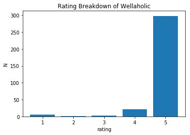

```python
selected_data = wellaholic_data
wellaholic_ratings = Counter(list(selected_data['starRatings']))
print(wellaholic_ratings)

plot_rating_breakdown(wellaholic_ratings, 'Rating Breakdown of Wellaholic')
```

If we were to aggregate all 3 regions' review ratings (KL, JB, Penang), they all look closer to J-curve then exponential like Wellaholic, as observed below:

```
Counter({5: 284, 1: 23, 4: 11, 2: 3, 3: 1})
```

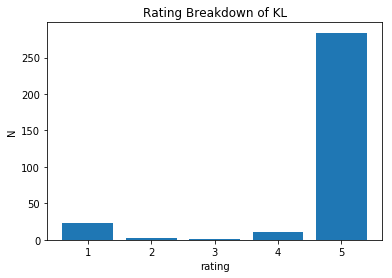

```python
kl_ratings = Counter(list(kl_data['starRatings']))
print(kl_ratings)

plot_rating_breakdown(kl_ratings, 'Rating Breakdown of KL')
```

```
Counter({5: 412, 1: 34, 4: 15, 3: 3, 2: 3})
```

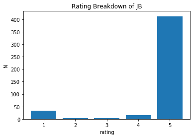

```python
jb_ratings = Counter(list(jb_data['starRatings']))
print(jb_ratings)

plot_rating_breakdown(jb_ratings, 'Rating Breakdown of JB')
```

```
Counter({5: 316, 1: 49, 4: 23, 3: 13, 2: 6})
```

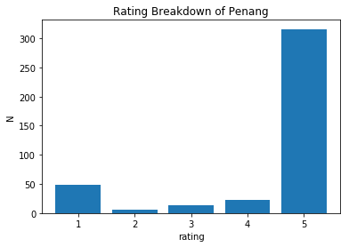

```python
penang_ratings = Counter(list(penang_data['starRatings']))
print(penang_ratings)

plot_rating_breakdown(penang_ratings, 'Rating Breakdown of Penang')
```

In conclusion, there are dissatisfied customers in all 3 regions as shown from the breakdown of their aggregate review ratings.

## B. WordCloud

First, we observe the common words in Wellaholic post reviews (all stars).

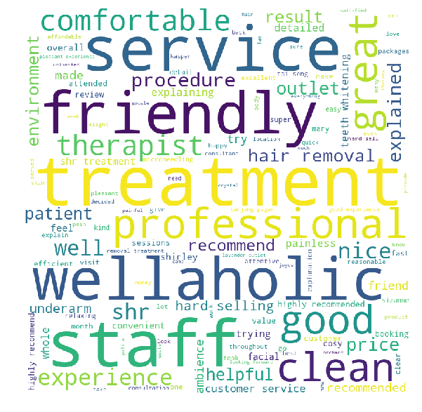

```
<wordcloud.wordcloud.WordCloud at 0x22678dd86d8>
```

```python
from wordcloud import WordCloud, STOPWORDS

def get_wordcloud(review_list, additional_stopwords, color='viridis'):
    common_words = ""
    for review in review_list:
        text = str(review).strip().lower().replace('\n', ' ').replace('\t', ' ')
        common_words += text

    stopwords = set(STOPWORDS)
    stopwords.update(additional_stopwords)

    wordcloud = WordCloud(width = 800, height = 800,
                    background_color ='white',
                    stopwords = stopwords,
                    colormap = color,
                    min_font_size = 10).generate(common_words)

    # plot the WordCloud image
    plt.figure(figsize = (8, 8), facecolor = None)
    plt.imshow(wordcloud)
    plt.axis("off")
    plt.tight_layout(pad = 0)
    plt.show()
    return wordcloud

postReviews = list(wellaholic_data['postReviews'])
additional_stopwords = ['done', 'see', 'appointment', 'process', 'today',
                        'time', 'will', 'next', 'went', 'signed', 'provided',
                        'first', 'package', 'definitely', 'always', 'thank', 'thanks'
                        'thank you', 'session', 'really', 'questions', 'place'
                       ]

wellaholic_cloud = get_wordcloud(postReviews, additional_stopwords)
wellaholic_cloud.to_file('./img/wellaholic_cloud.png')
```

Since the rating is overwhelmingly positive for wellaholic, we know for sure that these are the things that customers speak positively about. Furthermore, They alligned with what wellaholics tell us too!

e.g. no hard selling, friendly, helpful and professional service, good ambience, clean environment, detailed explanation about procedure, etc.

We can then compare this to 1-star ratings in the 3 regions

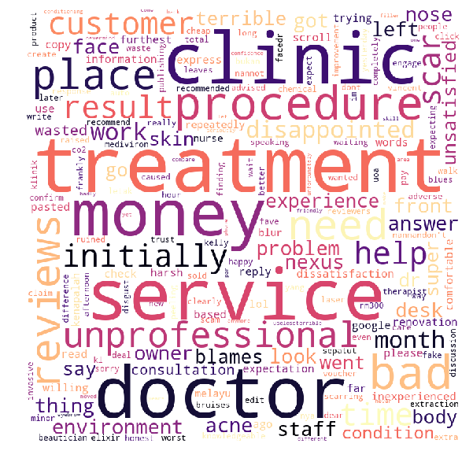

```
<wordcloud.wordcloud.WordCloud at 0x2267b659358>
```

```python
selected_rating = kl_data['starRatings'] == 1
selected_data = kl_data[selected_rating]

postReviews = list(selected_data['postReviews'])
additional_stopwords = ['review', 'want', 'will', 'see', 'done', 'say'
                        'google', 'follow', 'good', 'nice'
                       ]

color = 'magma'
kl_wordcloud = get_wordcloud(postReviews, additional_stopwords, color)
kl_wordcloud.to_file('./img/kl_wordcloud.png')
```

Using these negative keywords to highlight some notable 1 star comments from each region that contains these keywords.

```python
def print_reviews_containing(keywords, postReviews):
    reviews = []
    for review in postReviews:
        for keyword in keywords:
            if keyword in str(review).lower().strip().replace('\n', ' ').replace('\t', ' '):
                if str(review) in reviews: continue
                else: reviews.append(str(review))

    return reviews

selected_rating = kl_data['starRatings'] == 1
selected_data = kl_data[selected_rating]

postReviews = list(selected_data['postReviews'])
keywords = ['unprofessional', 'money', 'dissapointed', 'unsatisfied', 'procedure']
kl_notable_1_star = print_reviews_containing(keywords, postReviews)
kl_notable_1_star
```

```
["Don't waste your money and time for acne scarring treatment here. Didn't see any good improvement at all . And even create new scar on my face",
 'Dr Vincent completely ruined my nose when he advised me to pay an extra RM300 for a more invasive CO2 laser for a minor raised scar (I got the cheap voucher from fave). During the procedure he did not confirm with me the scar that I wanted …',
 "The worst experience ever. I went there for chemical peeling and they sold me more service. the Dr claim that i need to do extraction for better result. After the treatment I didn't see any difference. I do not  recommend it they want the money only. its scam my face looks the same and i got my ac…
 'The staff is super nice and friendly but unfortunately my procedure was very badly done and I was left unsatisfied. I had the same thing done a few years back in different clinic so I could compare their work... it was bad! I will never come there again.',
 "I'll say 4-5 stars for customer service and environment, but Dr. Renee's work is very unsatisfied. Plus like what the other comment says, she blames it on my own body condition!\nThat is very unprofessional because we find you to fix it but …",
 'Received disappointed consultation from the doctor. Wasted thousands on procedure that doesn’t work on me! Then the doctor blames it on my body condition! But before said procedure, I had already gone through few procedures with the same …',
 'SUPER DISAPPOINTED with the follow-up service by the beauty consultant Carrey! Suppose to get WEEKLY post-surgery follow-ups for the first six months as promised, but after few times within the 1st month, then no more follow-up, terrible service!! So unprofessional!!!',
 'This clinic sucks .... they rush you for treatments just for the sake of money ... they just need money !!! So unprofessional... I regret investing a lot here with no results  ... the doctors are so unprofessional !!!',
 'Very poor consultation from the doctor!!! \nWasted money on ineffective treatment!!! \n👎👎👎']
```

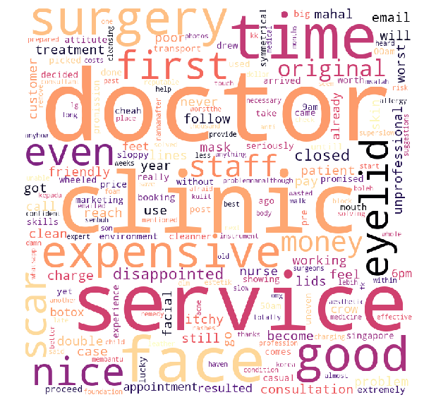

```
<wordcloud.wordcloud.WordCloud at 0x22678da20f0>
```

```python
selected_rating = jb_data['starRatings'] == 1
selected_data = jb_data[selected_rating]

postReviews = list(selected_data['postReviews'])
additional_stopwords = ['rid', 'now', 'anymore', 'wait', 'give', 'say'
                        'Google', 'went', 'day', 'dr', 'translated', 'nice'
                        'googletime', 'see', 'google', 'bad'
                       ]

color = 'magma'
jb_wordcloud = get_wordcloud(postReviews, additional_stopwords, color)
jb_wordcloud.to_file('./img/jb_wordcloud.png')
```

```python
selected_rating = jb_data['starRatings'] == 1
selected_data = jb_data[selected_rating]

postReviews = list(selected_data['postReviews'])
keywords = ['expensive', 'money', 'doctor', 'service', 'time', 'staff', 'dissapointed']
jb_notable_1_star = print_reviews_containing(keywords, postReviews)
jb_notable_1_star
```

```
['I had my double eyelid surgery done a few years ago. I used their transport services and they picked me up from Singapore. I arrived at 9am for a consultation and decided to proceed with the surgery on the same day. The nurse did not give …',
 'Pre service was good, but post service is bad. Went for a double eyelid surgery, doctor was sloppy and too casual, did not take it seriously, he just drew 2 lines on my eyelid without showing me and I was wheeled in. Was promised symmetrical lids, came out with EXTREMELY UNEVEN lids. Very bad expe…
 'Nice environment, and friendly customer service. But the price for the doctor skills and follow up patient case really not worth. After the treatment, there is no any follow up call nor email comes to me, only their marketing email.\n\n Lucky …',
 'Booking at 9.00am see Dr Cheah and wait untill now 9.50am Dr still not yet reach clinic, this doctor is not first time big mouth in his promission,he is nice doctor but his working attitute is poor then the cleanner in this clinic.',
 'customer service problem',
 'Although the doctor and the nurses are nice and friendly but the medical instrument and profession are not even in foundation. i have been there for my acne and there is not working at all after 1 months. Therefore, i went to other clinic it solved my problem within 2 weeks. Unprofessional, expens…
 'Went there to see dr for my old scar. Before I went to the clinic, I emailed them with photos of my scar and the staff mentioned about surgery to remove my scar with costs. Prepared the money and went down but the dr said not necessary to …',
 'Expensive, slow , have to wait for a long time and the medicine is not so effective... Better go KK..',
 'Superslow service!!!!',
 'Totally wasted my time and money for the past whole year and my skin condition become more worst thanks to them~~\n\nNever heard any good suggestions after my skin become worst',
 "(Translated by Google) It's expensive, it can't be too late ...\n\n(Original)\nMahal lg tk boleh senbuh..",
 '(Translated by Google) charge expensive .. x help in leather case .. more to aesthetic. doctor not so doctor\n\n(Original)\ncharge mahal.. x membantu dlm msalah kulit.. lebih kepada estetik. doctor not so doctor',
 '(Translated by Google) My child has to rashes one body..just for anti allergy and less itchy remedy. At the time of the touch check I did not ... pay more but my son was not good anymore. Had to go to another Clinic. The expert can not use …',
 'After walk in and do consultation. Haven’t start to do anything. Then the next day, the clinic block my WhatsApp and unable to call anymore. Seem like the clinic’s doctor not confident to provide best service to the patient and afraid …',
 'I did facial at this place.\nOmg damn bad service here.\nThey anyhow use cleansing foam clean my face? Which I can do it myself.\nAfter put mask, they dun even clean my facial well. Still got mask on my face surface.\nNow My face feel itchy, can feel that my face got some waste? This was my first …
 "Disappointed with my botox treatment at Foo Clinic. I went to get Botox to get rid of my crow's feet. The doctor managed to get rid of the crow's feet, but it resulted resulted in deep lines under my eyes (which i never had before). \n\nI …",
 'Operation hour the google and website it says closed at 6pm. However on a random Thursday it closed at 5.30pm. In fact I have already text the clinic at 4.55pm, staff saw the message (as it shown as blue tick), but did not reply , i was abit upset and disappointed, decide not to return anymore.',
 'Doctor  very no  good',
 '(Translated by Google) The dermatologist is more careful, but the doctor who sees the doctor is very chaotic.\n\n(Original)\n皮肤科的医生比较细心， 可是看病的医生很像乱乱教的。',
 'Back from work, rushing to your clinic, called  the staff i will reach before 6pm, 5:50pm already closed.',
 'Poor service.....spend money and get my face painful😡😡😡 just asked pay finish first.....all about🤑🤑🤑',
 'Poor services']
```

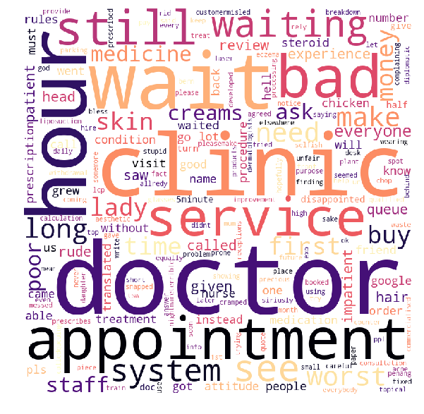

```
<wordcloud.wordcloud.WordCloud at 0x22678c944e0>
```

```python
selected_rating = penang_data['starRatings'] == 1
selected_data = penang_data[selected_rating]

postReviews = list(selected_data['postReviews'])
additional_stopwords = ['much', 'better', 'dr', 'oh', 'visit'
                        'still', 'almost', 'kind'
                       ]

color = 'magma'
penang_wordcloud = get_wordcloud(postReviews, additional_stopwords, color)
penang_wordcloud.to_file('./img/penang_wordcloud.png')
```

```python
selected_rating = penang_data['starRatings'] == 1
selected_data = penang_data[selected_rating]

postReviews = list(selected_data['postReviews'])
keywords = ['wait', 'waiting', 'still', 'hour', 'appointment', 'doctor', 'service']
penang_notable_1_star = print_reviews_containing(keywords, postReviews)
penang_notable_1_star
```

```
['The doctor has no LCP for Aesthetic Medicine. Not qualified.',
 'The worst skin clinic i have been to. If u have eczema or any skin conditions, pls be careful with the prescriptions that this doctor prescribes. I developed tsw(topical steroid withdrawal) after using steroid creams that he prescribed …',
 "call never answer. what kind of clinic can't even ask info or make appointment\nhire more ppl please",
 'Make appointment at 11.15 am still need to wait like hell ?!?!? Exo me ?? Everyone’s time is precious ok ! If make appointment still need to wait , what’s purpose for appointment ??',
 '5 hours waiting time just to see the doctor in a small cramped clinic, finding a parking spot is a nightmare',
 "terrible clinic that is unfair which let a selfish lady go in 1st to see DR after complaining about the waiting time and appointment saying she has no time to wait, she came 1 hour later than us, after she saw the DR, the lady didn't pay …",
 'The doctor is good, but the lady wearing glasses ( short one) she  didnt call the queue in order....i been waiting to see doctor for more than 2 hours..somemore people who came behind me allredy bern called',
 'Queuing system is messed. Need to be fixed soon for everyone sake. Poor patients have to wait without notice how long they must wait. Hopefully they will be better in the near future. God bless....',
 "Too commercialised.. .. In fact the doctor didn't help to get rid of my daughter's skin problem, instead make her rely on all the daily use products that have to buy from them every month.",
 "Have a high knowledge of doctor. No clinic system and don't know how to fix the long queue. Just know how to earn the people money. I just bought for medicine only, have wait for 2 hours. Bad service.",
 'Terrible service! \nAppointment at 11am but we are still waiting after 2 hours, what is the point of making appoitment?\nThey should computerized everything instead of manually control the patients to be called to see doctor! \nThe nurse told …',
 'The worst clinic I attend before , they only entertain the foreigners first , where I spent almost 4 hours there, but not able see doctor and finally I just walked away .There are no rules for “first in first out” perhaps the rules is “who …',
 'Worst of the worst clinic system ever i have experienced , waited 4hours still not able to see the doctor!!!!!!!!!!!!',
 'Bad customer service by the staff',
 '(Translated by Google) Bad service. Staff attitude is poor, the distribution of drugs to the guests did not follow the order, see the money to buy a lot of first give, buy less, always called, etc., also called back again, ask the question …',
 'Come with appointment date given by doctor but still have to wait more than 1 hour 10 minute. Whats a diffrent with or whithout appointment.treatment by doc just about 5minute ONLY.. ("waiting 1hour++ talk with doc just 5minute").pls do …',
 'Waiting for 1 hr. Then once it has finished, it takes so long to give the medicine until I need to chase. Totally disappointed .... the two malay guys outside act so slow...what the hell...',
 "Bad service, no system, racist! The person queue after us also done and go half an hour still haven't our turn!",
 'Visit O2 Clinic at Jelutong Branch on 22/2/2019. Waiting almost half an hour but just saw got 2 patience. This is slowest service I experience in clinic. 2nd is I saw doctor on duty on was Dr.Kerwin Oh but lastly entertained by a Indian …',
 "Very late service, and no system need to some changes on your system and upgrade.\nDon't make patient wait so long..",
 "Bad experience bad doctor Oh,  everyone must beware of him, don't trust their good review all not true.",
 'Worse doctor Oh so impatient and rude!',
 'Everytime also waited so long. Nurse and Doctor also impatient and rude!',
 'Doctor is impatient and rude!',
 'Bad service wait almost 2 hours still yet to reach my turn... ']
```

Wellaholic has the qualities mentioned during 1st week briefing. e.g. no hard selling, friendly, helpful and professional service, good ambience, clean environment, detailed explanation about procedure, etc.

Clinics in Penang suffers from appointment issues, long queues and waiting time, unprofessional doctors.